# PA1_template.Rmd

Francis Ivan Clado

May 10, 2019

## Loading and preprocessing the data

```r
library(ggplot2)
data <- read.csv("activity.csv")
```

## What is mean total number of steps taken per day?

Use the tapply function to calculate the total steps per day.

```r
total <- tapply(data$steps, data$date, FUN=sum, na.rm=TRUE)
```

Load the ggplot2 package and use the qplot function to create a histogram.

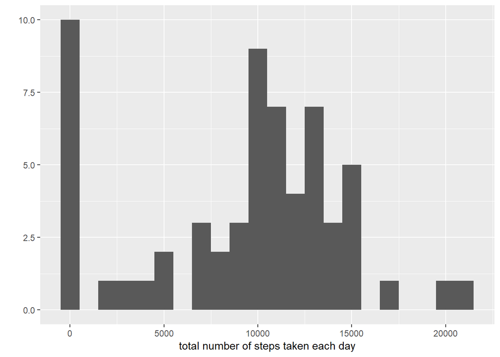

```r
library(ggplot2)
qplot(total, binwidth=1000, xlab="total number of steps taken each day")
```

Use the mean and median function.

```r
mean(total, na.rm=TRUE)
```

```
## [1] 9354.23
```

```r
median(total, na.rm=TRUE)
```

```
## [1] 10395
```

## What is the average daily activity pattern?

Call the aggregate function to get the average steps for each 5-minute interval.

```r
intervalsteps <- aggregate(x=list(steps=data$steps), by=list(interval=data$interval),
                      FUN=mean, na.rm=TRUE)
```

Use ggplot to create a time series plot.

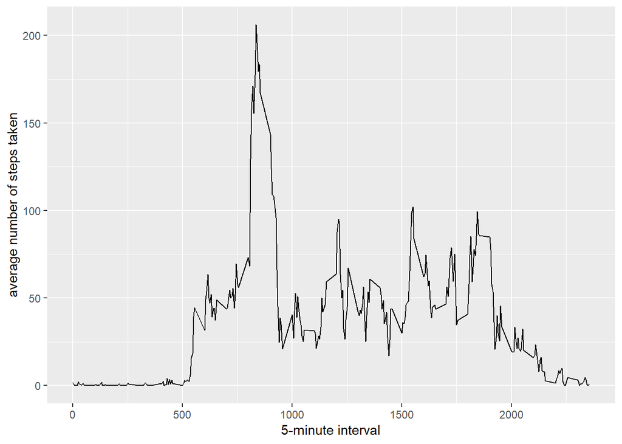

```r
ggplot(data=intervalsteps, aes(x=interval, y=steps)) +
  geom_line() +
  xlab("5-minute interval") +
  ylab("average number of steps taken")
```

Use the which and max function to determine Which 5-minute interval contains the maximum number of steps.

```r
intervalsteps[which.max(intervalsteps$steps),]
```

```
##     interval    steps
## 104      835 206.1698
```

## Imputing missing values

```r
nas <- is.na(data$steps)
length(nas[nas==TRUE])
```

```
## [1] 2304
```

```r
data[is.na(data)] <- mean(data$steps)
```

## Are there differences in activity patterns between weekdays and weekends?

Create a function that determines if a given date is a weekday or weekend.

```r
daytype <- function(date) {
type <- ""
type <- ifelse(weekdays(date) %in% c("Saturday", "Sunday"), "Weekend", "Weekday")
type
}
```

Convert the values in data$date into a date class. Use sapply to use the created function on each date. Convert the daytype values into a factor variable with two levels.

```r
data$date <- as.Date(data$date)
data$daytype <- sapply(data$date, FUN=daytype)
data$daytype <- as.factor(data$daytype)
```

Use the aggregate function and ggplot to create a panel plot containing a time series plot of the 5-minute interval (x-axis) and the average number of steps taken, averaged across all weekday days or weekend days (y-axis).

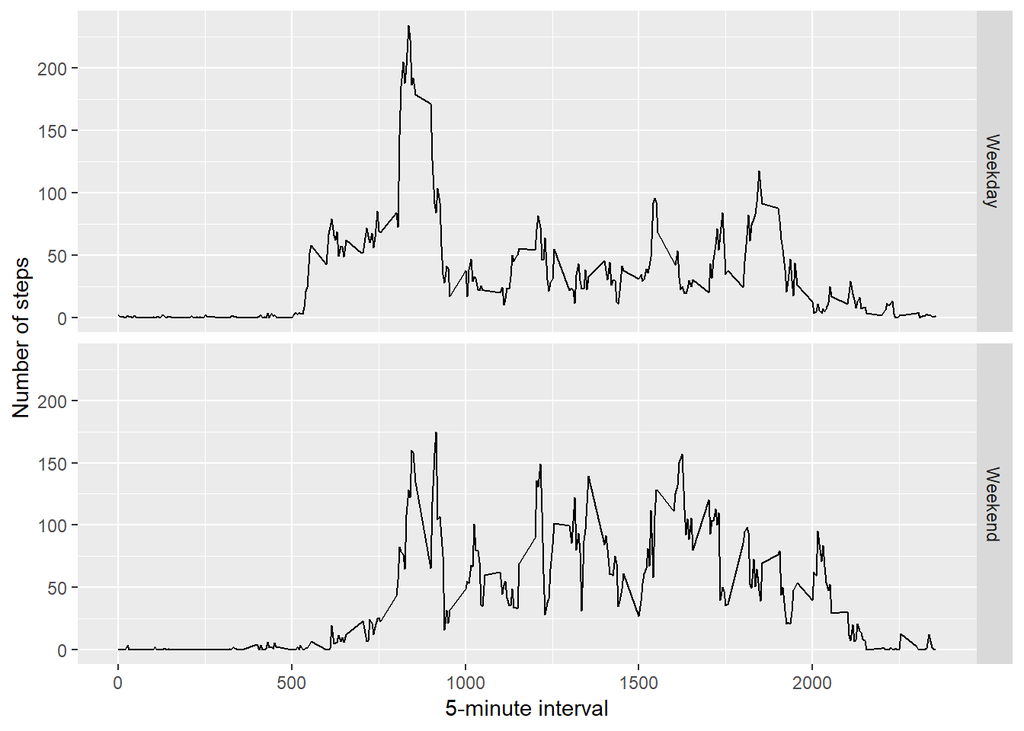

```r
panelplot <- aggregate(steps ~ interval + daytype, data=data, mean)
ggplot(panelplot, aes(interval, steps)) + geom_line() + facet_grid(daytype ~ .) +
  xlab("5-minute interval") + ylab("Number of steps")
```